# HF Statistics 2

## 2장. 중심적 경향 파악하기

1장에서는 시각화를 통해 단순히 나열되어 이해하기 어려운 데이터를 보다 쉽게 파악할 수 있다는 것을 배웠습니다.

2장에서는 데이터를 바라보는 대표적인 기준점 세 가지, ‘평균값’, ‘중앙값’, ’최빈값’을 배우고 데이터의 경향성을 파악하는 연습을 해보겠습니다.

왜 이러한 기준점들을 알아야 할까요. 예시를 들어 설명해보죠. 취업준비생 철수는 연봉이 높은 회사에 입사하고 싶습니다. 그가 알고 싶은 정보는 두 가지 입니다. 신입사원인 자신이 받을 급여와 중간관리자급이 되었을 때의 급여입니다. 취업정보 사이트에서 확인해본 결과 세 회사 A, B, C의 평균 연봉은 각각 3000, 4000, 5000만 원이라고 합니다. 철수는 마음편히 C회사를 선택하면 되겠군요.

그렇지 않습니다. 평균 연봉은 모든 임직원의 연봉을 더해 사람 수로 나눈 수치입니다. C회사에는 10억 이상의 임원들이 많아 평균이 비정상적으로 높아졌을지도 모릅니다. 물론 철수가 그들을 롤모델로 삼아 열심히 일할 수는 있겠으나, 현실적으로 향후 10년 내에는 어려울 것 같습니다.

먼저 신입사원의 급여를 확인하고자 한다면 연봉의 ’최빈값’을 알아야 합니다. 일반적으로 회사의 조직도는 직급이 높아질 수록 인원이 적어지는 피라미드 형태이고 사원급이 가장 많을 것이기 때문입니다. 다음으로 중간관리자의 연봉을 알고싶다면 ’중앙값’을 확인하는 것이 좋겠네요. 임직원을 연봉 액수로 오름차순으로 일렬로 세웠을 때 중앙에 있는 사람이 5년 내지는 10년 후의 철수의 모습일테니 말이죠.

이렇듯 원하는 정보가 같다해도 상황에 따라 필요한 정보가 다를 수 있습니다. 다양한 환경에서 효과적인 정보를 선별하기 위해서 우리는 각 기준들이 무엇을 의미하는지, 또 언제 사용하면 좋은지 알아야 합니다.

### 평균값, 중앙값, 최빈값

35세 철수는 체육센터에서 수업을 수강하려 합니다. 그는 수강인원의 연령대가 자신과 비슷한 30대 중반의 수업을 들으려 합니다. 쿵푸교실의 평균 연령이 34살이라고 하네요. 그는 쿵푸교실에 들어갔습니다. 회원들의 연령 분포를 한눈에 보기 위해 그래프(히스토그램)으로 나타내보겠습니다.

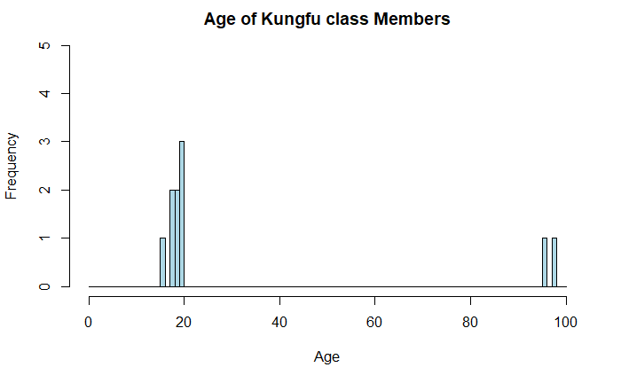

```r
kungfu <- c(16,18,18,19,19,20,20,20,96,98)
hist.kungfu <- hist(kungfu, xlab = "Age", breaks = seq(0,100), xlim = c(0,100), ylim = c(0,5), main = "Age of Kungfu class Members", col = "light blue")
```

쿵푸교실에는 30,40대 회원이 없고 젊은(10,20대) 회원들이 대부분이었습니다. 어떻게 된 일일까요.

```r
kungfu <- c(16,18,18,19,19,20,20,20,96,98)
length(kungfu)
```

```
[1] 10
```

```r
 # length() 함수 : length함수는 요소들의 갯수를 알려줍니다.
sum(kungfu)
```

```
[1] 344
```

```r
 # sum() 함수 : sum함수는 각 요소들의 합을 알려줍니다.
mean(kungfu)
```

```
[1] 34.4
```

```r
 # mean() 함수 : mean함수는 각 값들을 모두 더한 뒤 갯수로 나눈 평균값을 보여줍니다.
average.kungfu = sum(kungfu) / length(kungfu)
 #average.kungfu 쿵푸교실 나이의 평균값을 average.kungfu를 각 요소들의 합을 그 갯수로 나눈 값( = sum(kungfu) / length(kungfu) )으로 정의했습니다. average.kungfu의 값과 mean(kungfu)의 값이 34.4로 동일한 것을 확인 할 수 있습니다.
d <- data.frame(xrow = "kungfu class", length(kungfu), sum(kungfu), mean(kungfu), average.kungfu)
d
```

| xrow | length.kungfu. | sum.kungfu. | mean.kungfu. | average.kungfu |
| --- | --- | --- | --- | --- |
| kungfu class | 10 | 344 | 34.4 | 34.4 |

일반적 분포에서 벗어난 초고령(96과 98세) 회원들이 평균값을 올렸기 때문입니다. 이렇게 다른 값들에 비해 지나치게 크거나 작은 극단적인 값을 이상치 또는 이상값(outlier)이라고 부릅니다. 이렇듯 평균은 이상값에 영향을 많이 받습니다. 반대로 이상값으로부터 영향을 크게 받지 않는 통계량을 ’로버스트(robust)’하다고 표현합니다.

이 경우 ’쿵푸교실 회원 나이’라는 데이터를 대표하는 값으로 평균값이 적절하지 않다는 것을 확인했습니다. 어떤 데이터를 자료의 특징을 수 하나로 표현한 값을 대푯값이라고 합니다.

17살 영희는 수영교실에 들어가고 싶습니다. 다음으로, 중앙값은 순서를 나열했을 때 중앙에 있는 값을 말합니다. 중앙값은 숫자의 개수에 따라 구하는 법이 다릅니다. 홀수일 때는 가운데 숫자를, 짝수일 때는 가운데 두 숫자를 더하고 절반으로 나눈 값을 사용합니다. 중앙값은 데이터가 이상치(outlier), 즉 극단적인 값을 포함할 때 사용합니다. 순서를 나타내는 값이기 때문에 극단적인 크기를 배제할 수 있는 것이죠.

p.104

```r
a <- c(1,1,1,1,2,2,2,2,2,2,3,3,3,3,4,4,4,4,5,5,5,6,6,7,8)
b <- c(1,4,6,6,8,8,8,9,9,9,9,10,10,10,10,11,11,11,11,11,12,12,12,12,12)

length(a)
length(b)
 # 데이터 a와 b는 각각 25개의 수(홀수개)로 이루어져 있습니다. 따라서 한 가운데인 13번 째 값이 중앙값입니다.

median(a)
median(b)
 # 각각의 중앙값은 3과 10입니다.

mean(a)
mean(b)
 # 각각의 평균값은 3.44와 9.28입니다.

d <- data.frame(xrow = c("a","b"),
                Median = c(median(a), median(b)),
                Mean = c(mean(a), mean(b)))
d
 #

hist(a)
hist(b)
```

[output not shown]

마지막으로 최빈값은 가장 많이 나타난, 다시말해 도수(frequency)가 가장 높은 값을 말합니다. 최빈값은 범주적 데이터를 다룰 수 있으며, 복수의 데이터 그룹을 비교할 수 있어 그 값이 하나 이상일 수 있습니다. 그럴 때는 그룹당 한 개의 최빈값을 구해줍니다.

### 평균값과 중앙값의 비교

평균값과 중앙값을 통해 우리는 데이터가 왼쪽이나 오른쪽으로 치우친 정도(좌/우 편향성)을 알 수 있습니다.

두 가지 경우가 있겠죠. 평균값이 중앙값의 왼쪽에 있는 경우와 오른쪽에 있는 경우로 말이죠.

전자는 무엇을 의미할까요. 1) 중앙값이 오른쪽에 있다 = 높은 숫자들이 많이 있는데 2) 평균은 왼쪽에 있다 = 높은 숫자들을 상쇄하는 굉장히 낮은 숫자가 더러 있다.

후자는 그 반대겠죠. 1) 중앙값이 왼쪽에 있다 = 낮은 숫자들이 많이 있는데 2) 평균은 오른쪽에 있다 = 낮은 숫자들을 상쇄할 매우 높은 숫자가 몇 개 있다.

p.95

```r
powerwalk = c(19,20,20,20,21)
kungfu = c(19,19,19,20,20,20,20,20,20,21,21,21,145,147)

hist(powerwalk, breaks=c(18,19,20,21,22,23))
lines(density(powerwalk),col="red")
hist(kungfu, breaks = c(19,20,21,22,145,146,147,148))
lines(density(kungfu), col="red")


median(powerwalk)
median(kungfu)
```

[output not shown]

p.103

```r
x1 = c(1,1,1,1, 2,2,2,2,2,2, 3,3,3,3, 4,4,4,4, 5,5,5, 6,6, 7, 8)
x2 = c(1, 4, 6,6, 8,8,8, 9,9,9,9, 10,10,10,10, 11,11,11,11,11, 12,12,12,12,12)

hist(x1)
scatter.smooth(x1)
```

[output not shown]

p.107

```r
x1=c(1,2,3,31,32,33)
y1=c(3,4,2,2,4,3)

swim = c(1,1,1, 2,2,2,2, 3,3, 31,31, 32,32,32,32, 33,33,33)

barplot(swim)
hist(swim, breaks = c(0,34,by=35))


matrix(c(1,2,3,4,5,6), ncol=2)

barplot(swim)
```

[output not shown]